# Alternative clustering for Plex data

We have been asked by a reviewer to provide details on why we did what we did in terms of clustering. Here, I want to try out a different clustering approach to see if we get overlapping clustering and how sensitive the cluster borders are to different paramters.

I thought I could try and use the Seurat workflow and ‘pretend’ that the magic table is sc RNAseq data. I have mainly been following this tutorial https://satijalab.org/seurat/articles/pbmc3k_tutorial.html

Loading libraries

```r
library(Seurat)
library(tidyverse)
```

Importing the interaction pair data

```r
read_tsv("../data/umap_mark_data_uncapped.txt") -> marks_import
head(marks_import)
```

| interaction_ID | UMAP1 | UMAP2 | P_ID | PIR_ID | P_gene | PIR_gene | CHiC_DNMT_KO_EpiLC_D2 | CHiC_DNMT_KO_ES_D0 | CHiC_DNMT_WT_EpiLC_D2 | CHiC_DNMT_WT_ES_D0 | CHiC_TET_KO_EpiLC_D2 | CHiC_TET_KO_ES_D0 | CHiC_TET_WT_EpiLC_D2 | CHiC_TET_WT_ES_D0 | P_mC_DNMT_WT_ES_D0 | P_mC_DNMT_WT_EpiLC_D2 | P_mC_TET_WT_ES_D0 | P_mC_TET_WT_EpiLC_D2 | P_mC_TET_KO_ES_D0 | P_mC_TET_KO_EpiLC_D2 | PIR_mC_DNMT_WT_ES_D0 | PIR_mC_DNMT_WT_EpiLC_D2 | PIR_mC_TET_WT_ES_D0 | PIR_mC_TET_WT_EpiLC_D2 | PIR_mC_TET_KO_ES_D0 | PIR_mC_TET_KO_EpiLC_D2 | P_hmC_TET_WT_ES_D0 | P_hmC_TET_WT_EpiLC_D2 | P_hmC_DNMT_WT_EpiLC_D2 | … |
| --- | --- | --- | --- | --- | --- | --- | --- | --- | --- | --- | --- | --- | --- | --- | --- | --- | --- | --- | --- | --- | --- | --- | --- | --- | --- | --- | --- | --- | --- | --- |
| 1_3100832_3102475...1_88213534_88213918 | -7.736398 | 2.661268 | 1_3100832_3102475 | 1_88213534_88213918 | NA | NA | 8.110911 | 21.034346 | 7.1204144 | 1.225626 | 0.000000 | 0.0000000 | 0.0000000 | 1.563273 | 1.158808 | 37.17698 | 18.98997 | 42.52453 | 49.0287 | 75.91344 | 2.302630 | 42.73777 | 24.25998 | 46.52147 | 42.17809 | 60.20813 | 0.05197199 | 0.008601253 | 0.01589082 | … |
| 1_3100832_3102475...1_88219912_88220831 | -7.640635 | 2.543528 | 1_3100832_3102475 | 1_88219912_88220831 | NA | NA | 1.343195 | 21.017586 | 0.9616277 | 7.499996 | 20.274226 | 19.7786822 | 13.6465230 | 20.009313 | 1.158808 | 37.17698 | 18.98997 | 42.52453 | 49.0287 | 75.91344 | 3.683014 | 39.84996 | 18.71493 | 39.16750 | 38.14064 | 53.40742 | 0.05197199 | 0.008601253 | 0.01589082 | … |
| 1_3100832_3102475...1_88220832_88222715 | -7.588283 | 2.662663 | 1_3100832_3102475 | 1_88220832_88222715 | NA | NA | 7.673024 | 14.235392 | 0.9616498 | 13.996533 | 13.610329 | 19.7796432 | 7.1979752 | 7.093898 | 1.158808 | 37.17698 | 18.98997 | 42.52453 | 49.0287 | 75.91344 | 3.683014 | 39.84996 | 18.71493 | 39.16750 | 38.14064 | 53.40742 | 0.05197199 | 0.008601253 | 0.01589082 | … |
| 1_3100832_3102475...1_88239615_88243256 | -7.587952 | 2.421477 | 1_3100832_3102475 | 1_88239615_88243256 | NA | NA | 1.343565 | 21.037692 | 13.5127725 | 13.997334 | 7.148573 | 6.9134002 | 13.6471740 | 7.094377 | 1.158808 | 37.17698 | 18.98997 | 42.52453 | 49.0287 | 75.91344 | 1.906809 | 54.41014 | 22.50960 | 49.08160 | 50.25687 | 69.41440 | 0.05197199 | 0.008601253 | 0.01589082 | … |
| 1_3100832_3102475...1_88248977_88249989 | -7.611894 | 2.500078 | 1_3100832_3102475 | 1_88248977_88249989 | NA | NA | 1.343706 | 0.000000 | 0.9620860 | 1.226275 | 7.148706 | 13.2586298 | 13.6474078 | 7.094573 | 1.158808 | 37.17698 | 18.98997 | 42.52453 | 49.0287 | 75.91344 | 1.221640 | 43.32586 | 19.20653 | 49.06848 | 43.35247 | 65.98791 | 0.05197199 | 0.008601253 | 0.01589082 | … |
| 1_3100832_3102475...1_88249990_88253144 | -7.732681 | 2.650164 | 1_3100832_3102475 | 1_88249990_88253144 | NA | NA | 1.343742 | 1.283993 | 7.1213814 | 1.226313 | 7.148740 | 0.8116416 | 0.9978581 | 20.009270 | 1.158808 | 37.17698 | 18.98997 | 42.52453 | 49.0287 | 75.91344 | 1.342959 | 47.28128 | 21.61995 | 50.53860 | 46.85413 | 68.49798 | 0.05197199 | 0.008601253 | 0.01589082 | … |

```r
colnames(marks_import)
```

```
  [1] "interaction_ID"                "UMAP1"                         "UMAP2"                         "P_ID"
  [5] "PIR_ID"                        "P_gene"                        "PIR_gene"                      "CHiC_DNMT_KO_EpiLC_D2"
  [9] "CHiC_DNMT_KO_ES_D0"            "CHiC_DNMT_WT_EpiLC_D2"         "CHiC_DNMT_WT_ES_D0"            "CHiC_TET_KO_EpiLC_D2"
 [13] "CHiC_TET_KO_ES_D0"             "CHiC_TET_WT_EpiLC_D2"          "CHiC_TET_WT_ES_D0"             "P_mC_DNMT_WT_ES_D0"
 [17] "P_mC_DNMT_WT_EpiLC_D2"         "P_mC_TET_WT_ES_D0"             "P_mC_TET_WT_EpiLC_D2"          "P_mC_TET_KO_ES_D0"
 [21] "P_mC_TET_KO_EpiLC_D2"          "PIR_mC_DNMT_WT_ES_D0"          "PIR_mC_DNMT_WT_EpiLC_D2"       "PIR_mC_TET_WT_ES_D0"
 [25] "PIR_mC_TET_WT_EpiLC_D2"        "PIR_mC_TET_KO_ES_D0"           "PIR_mC_TET_KO_EpiLC_D2"        "P_hmC_TET_WT_ES_D0"
 [29] "P_hmC_TET_WT_EpiLC_D2"         "P_hmC_DNMT_WT_EpiLC_D2"        "P_ATAC_DNMT_KO_EpiLC_D2"       "P_ATAC_DNMT_KO_ES_D0"
 [33] "P_ATAC_DNMT_WT_EpiLC_D2"       "P_ATAC_DNMT_WT_ES_D0"          "P_ATAC_TET_KO_EpiLC_D2"        "P_ATAC_TET_KO_ES_D0"
 [37] "P_ATAC_TET_WT_EpiLC_D2"        "P_ATAC_TET_WT_ES_D0"           "P_CTCF_DNMT_KO_EpiLC_D2"       "P_CTCF_DNMT_KO_ES_D0"
 [41] "P_CTCF_DNMT_WT_EpiLC_D2"       "P_CTCF_DNMT_WT_ES_D0"          "P_CTCF_TET_KO_EpiLC_D2"        "P_CTCF_TET_KO_ES_D0"
 [45] "P_CTCF_TET_WT_EpiLC_D2"        "P_CTCF_TET_WT_ES_D0"           "P_H3K27ac_DNMT_KO_EpiLC_D2"    "P_H3K27ac_DNMT_KO_ES_D0"
 [49] "P_H3K27ac_DNMT_WT_EpiLC_D2"    "P_H3K27ac_DNMT_WT_ES_D0"       "P_H3K27ac_TET_KO_EpiLC_D2"     "P_H3K27ac_TET_KO_ES_D0"
 [53] "P_H3K27ac_TET_WT_EpiLC_D2"     "P_H3K27ac_TET_WT_ES_D0"        "P_H3K27me3_DNMT_KO_EpiLC_D2"   "P_H3K27me3_DNMT_KO_ES_D0"
 [57] "P_H3K27me3_DNMT_WT_EpiLC_D2"   "P_H3K27me3_DNMT_WT_ES_D0"      "P_H3K27me3_TET_KO_EpiLC_D2"    "P_H3K27me3_TET_KO_ES_D0"
```

[output cut: 22 more lines]

Retaining only the columns that should go into clustering

```r
marks_import %>%
  select(-contains("UMAP"), -P_ID, -PIR_ID, -P_gene, -PIR_gene, -contains("Input"), -cluster_ID, -cluster_group) %>% # the labels and marks I don't want
  select(-contains("DNMT"), -contains("ES"), -contains("KO")) -> marks # limiting to Epi and TET and WT
head(marks)
```

| interaction_ID | CHiC_TET_WT_EpiLC_D2 | P_mC_TET_WT_EpiLC_D2 | PIR_mC_TET_WT_EpiLC_D2 | P_hmC_TET_WT_EpiLC_D2 | P_ATAC_TET_WT_EpiLC_D2 | P_CTCF_TET_WT_EpiLC_D2 | P_H3K27ac_TET_WT_EpiLC_D2 | P_H3K27me3_TET_WT_EpiLC_D2 | P_H3K4me1_TET_WT_EpiLC_D2 | P_H3K4me3_TET_WT_EpiLC_D2 | PIR_hmC_TET_WT_EpiLC_D2 | PIR_ATAC_TET_WT_EpiLC_D2 | PIR_CTCF_TET_WT_EpiLC_D2 | PIR_H3K27ac_TET_WT_EpiLC_D2 | PIR_H3K27me3_TET_WT_EpiLC_D2 | PIR_H3K4me1_TET_WT_EpiLC_D2 | PIR_H3K4me3_TET_WT_EpiLC_D2 |
| --- | --- | --- | --- | --- | --- | --- | --- | --- | --- | --- | --- | --- | --- | --- | --- | --- | --- |
| 1_3100832_3102475...1_88213534_88213918 | 0.0000000 | 42.52453 | 46.52147 | 0.008601253 | 0.2898391 | 0.3974883 | 0.2264807 | 0.2771709 | 0.1846607 | 0.01003837 | 0.5843963 | 0 | 0 | 0 | 0 | 0 | 0 |
| 1_3100832_3102475...1_88219912_88220831 | 13.6465230 | 42.52453 | 39.16750 | 0.008601253 | 0.2898391 | 0.3974883 | 0.2264807 | 0.2771709 | 0.1846607 | 0.01003837 | 0.1892864 | 0 | 0 | 0 | 0 | 0 | 0 |
| 1_3100832_3102475...1_88220832_88222715 | 7.1979752 | 42.52453 | 39.16750 | 0.008601253 | 0.2898391 | 0.3974883 | 0.2264807 | 0.2771709 | 0.1846607 | 0.01003837 | 0.0646041 | 0 | 0 | 0 | 0 | 0 | 0 |
| 1_3100832_3102475...1_88239615_88243256 | 13.6471740 | 42.52453 | 49.08160 | 0.008601253 | 0.2898391 | 0.3974883 | 0.2264807 | 0.2771709 | 0.1846607 | 0.01003837 | 1.0575976 | 0 | 0 | 0 | 0 | 0 | 0 |
| 1_3100832_3102475...1_88248977_88249989 | 13.6474078 | 42.52453 | 49.06848 | 0.008601253 | 0.2898391 | 0.3974883 | 0.2264807 | 0.2771709 | 0.1846607 | 0.01003837 | 0.5141660 | 0 | 0 | 0 | 0 | 0 | 0 |
| 1_3100832_3102475...1_88249990_88253144 | 0.9978581 | 42.52453 | 50.53860 | 0.008601253 | 0.2898391 | 0.3974883 | 0.2264807 | 0.2771709 | 0.1846607 | 0.01003837 | 0.4834111 | 0 | 0 | 0 | 0 | 0 | 0 |

Transposing this so it can be made into a Seurat object

```r
marks %>%
  column_to_rownames(var = "interaction_ID") %>%
  t() %>%
  as.data.frame() -> marks_transposed

head(marks_transposed)
```

|  | 1_3100832_3102475...1_88213534_88213918 | 1_3100832_3102475...1_88219912_88220831 | 1_3100832_3102475...1_88220832_88222715 | 1_3100832_3102475...1_88239615_88243256 | 1_3100832_3102475...1_88248977_88249989 | 1_3100832_3102475...1_88249990_88253144 | 1_3100832_3102475...1_88253145_88256613 | 1_3100832_3102475...1_88256614_88257752 | 1_3100832_3102475...1_88257753_88261254 | 1_3100832_3102475...1_88274375_88276240 | 1_3100832_3102475...1_88278578_88280173 | 1_3100832_3102475...10_113211613_113213951 | 1_3465870_3467675...1_3004106_3005820 | 1_3465870_3467675...1_88213534_88213918 | 1_3465870_3467675...1_88219912_88220831 | 1_3465870_3467675...1_88220832_88222715 | 1_3465870_3467675...1_88239615_88243256 | 1_3465870_3467675...1_88248977_88249989 | 1_3465870_3467675...1_88249990_88253144 | 1_3465870_3467675...1_88253145_88256613 | 1_3465870_3467675...1_88256614_88257752 | 1_3465870_3467675...1_88257753_88261254 | 1_3465870_3467675...1_88265757_88265934 | 1_3465870_3467675...1_88274375_88276240 | 1_3465870_3467675...1_88278578_88280173 | 1_3465870_3467675...10_113211613_113213951 | 1_3465870_3467675...17_23341598_23342019 | 1_3465870_3467675...17_23514824_23517493 | 1_3669625_3675236...1_4135011_4135938 | … |
| --- | --- | --- | --- | --- | --- | --- | --- | --- | --- | --- | --- | --- | --- | --- | --- | --- | --- | --- | --- | --- | --- | --- | --- | --- | --- | --- | --- | --- | --- | --- |
| CHiC_TET_WT_EpiLC_D2 | 0.000000000 | 13.646522977 | 7.197975205 | 13.647173965 | 13.647407810 | 0.997858114 | 0.997902220 | 0.000000000 | 0.997963807 | 13.648212139 | 7.199228986 | 17.440555681 | 2.86036966 | 0.47594190 | 0.00000000 | 0.00000000 | 5.51284566 | 11.43857430 | 26.03200588 | 5.51303778 | 0.00000000 | 17.56756983 | 6.42155043 | 0.00000000 | 11.43918565 | 1.42006445 | 2.59854148 | 2.59854148 | 0.85023099 | … |
| P_mC_TET_WT_EpiLC_D2 | 42.524532318 | 42.524532318 | 42.524532318 | 42.524532318 | 42.524532318 | 42.524532318 | 42.524532318 | 42.524532318 | 42.524532318 | 42.524532318 | 42.524532318 | 42.524532318 | 48.78004074 | 48.78004074 | 48.78004074 | 48.78004074 | 48.78004074 | 48.78004074 | 48.78004074 | 48.78004074 | 48.78004074 | 48.78004074 | 48.78004074 | 48.78004074 | 48.78004074 | 48.78004074 | 48.78004074 | 48.78004074 | 9.80400158 | … |
| PIR_mC_TET_WT_EpiLC_D2 | 46.521472931 | 39.167495728 | 39.167495728 | 49.081598282 | 49.068481445 | 50.538597107 | 51.836059570 | 51.663406372 | 63.005840302 | 56.323158264 | 56.154880524 | 30.791986465 | 48.28691483 | 46.52147293 | 39.16749573 | 39.16749573 | 49.08159828 | 49.06848145 | 50.53859711 | 51.83605957 | 51.66340637 | 63.00584030 | 76.05055237 | 56.32315826 | 56.15488052 | 30.79198647 | 32.98315811 | 33.45278549 | 65.25506020 | … |
| P_hmC_TET_WT_EpiLC_D2 | 0.008601253 | 0.008601253 | 0.008601253 | 0.008601253 | 0.008601253 | 0.008601253 | 0.008601253 | 0.008601253 | 0.008601253 | 0.008601253 | 0.008601253 | 0.008601253 | 0.03686037 | 0.03686037 | 0.03686037 | 0.03686037 | 0.03686037 | 0.03686037 | 0.03686037 | 0.03686037 | 0.03686037 | 0.03686037 | 0.03686037 | 0.03686037 | 0.03686037 | 0.03686037 | 0.03686037 | 0.03686037 | 0.07774241 | … |
| P_ATAC_TET_WT_EpiLC_D2 | 0.289839149 | 0.289839149 | 0.289839149 | 0.289839149 | 0.289839149 | 0.289839149 | 0.289839149 | 0.289839149 | 0.289839149 | 0.289839149 | 0.289839149 | 0.289839149 | 0.55936950 | 0.55936950 | 0.55936950 | 0.55936950 | 0.55936950 | 0.55936950 | 0.55936950 | 0.55936950 | 0.55936950 | 0.55936950 | 0.55936950 | 0.55936950 | 0.55936950 | 0.55936950 | 0.55936950 | 0.55936950 | 1.92330444 | … |
| P_CTCF_TET_WT_EpiLC_D2 | 0.397488326 | 0.397488326 | 0.397488326 | 0.397488326 | 0.397488326 | 0.397488326 | 0.397488326 | 0.397488326 | 0.397488326 | 0.397488326 | 0.397488326 | 0.397488326 | 0.44239542 | 0.44239542 | 0.44239542 | 0.44239542 | 0.44239542 | 0.44239542 | 0.44239542 | 0.44239542 | 0.44239542 | 0.44239542 | 0.44239542 | 0.44239542 | 0.44239542 | 0.44239542 | 0.44239542 | 0.44239542 | 0.70928711 | … |

Making this into a Seurat object

```r
CreateSeuratObject(counts = marks_transposed, assay = "mark") -> marks_Seurat
```

LogNormalising the values

```r
marks_normalised <- NormalizeData(marks_Seurat)
```

Scaling the data

```r
all.marks <- rownames(marks_normalised)
marks_scaled <- ScaleData(marks_normalised, features = all.marks)
```

performing linear dimensional reduction

```r
marks_PCA <- RunPCA(marks_scaled, features = all.marks)
```

```
Warning: You're computing too large a percentage of total singular values, use a standard svd instead.Warning: Requested number is larger than the number of available items (17). Setting to 17.Warning: Requested number is larger than the number of available items (17). Setting to 17.Warning: Request…
Positive:  P-H3K27ac-TET-WT-EpiLC-D2, P-H3K4me1-TET-WT-EpiLC-D2, P-ATAC-TET-WT-EpiLC-D2, P-H3K4me3-TET-WT-EpiLC-D2, PIR-H3K27ac-TET-WT-EpiLC-D2, PIR-H3K4me1-TET-WT-EpiLC-D2, PIR-ATAC-TET-WT-EpiLC-D2, PIR-H3K4me3-TET-WT-EpiLC-D2
Negative:  P-mC-TET-WT-EpiLC-D2, PIR-mC-TET-WT-EpiLC-D2, PIR-H3K27me3-TET-WT-EpiLC-D2, P-H3K27me3-TET-WT-EpiLC-D2, CHiC-TET-WT-EpiLC-D2, P-hmC-TET-WT-EpiLC-D2, PIR-hmC-TET-WT-EpiLC-D2, PIR-CTCF-TET-WT-EpiLC-D2
PC_ 2
Positive:  PIR-H3K4me3-TET-WT-EpiLC-D2, P-mC-TET-WT-EpiLC-D2, PIR-ATAC-TET-WT-EpiLC-D2, PIR-H3K27ac-TET-WT-EpiLC-D2, PIR-H3K4me1-TET-WT-EpiLC-D2, PIR-CTCF-TET-WT-EpiLC-D2, P-hmC-TET-WT-EpiLC-D2, PIR-hmC-TET-WT-EpiLC-D2
Negative:  PIR-mC-TET-WT-EpiLC-D2, P-H3K4me3-TET-WT-EpiLC-D2, P-ATAC-TET-WT-EpiLC-D2, P-H3K27ac-TET-WT-EpiLC-D2, P-H3K4me1-TET-WT-EpiLC-D2, P-CTCF-TET-WT-EpiLC-D2, P-H3K27me3-TET-WT-EpiLC-D2, CHiC-TET-WT-EpiLC-D2
PC_ 3
Positive:  P-H3K27me3-TET-WT-EpiLC-D2, PIR-H3K27me3-TET-WT-EpiLC-D2, P-hmC-TET-WT-EpiLC-D2, P-CTCF-TET-WT-EpiLC-D2, PIR-CTCF-TET-WT-EpiLC-D2, P-H3K4me1-TET-WT-EpiLC-D2, PIR-hmC-TET-WT-EpiLC-D2, P-mC-TET-WT-EpiLC-D2
Negative:  P-H3K27ac-TET-WT-EpiLC-D2, PIR-H3K27ac-TET-WT-EpiLC-D2, PIR-H3K4me3-TET-WT-EpiLC-D2, P-H3K4me3-TET-WT-EpiLC-D2, PIR-H3K4me1-TET-WT-EpiLC-D2, P-ATAC-TET-WT-EpiLC-D2, PIR-ATAC-TET-WT-EpiLC-D2, CHiC-TET-WT-EpiLC-D2
PC_ 4
Positive:  PIR-H3K27me3-TET-WT-EpiLC-D2, PIR-CTCF-TET-WT-EpiLC-D2, P-H3K27me3-TET-WT-EpiLC-D2, PIR-ATAC-TET-WT-EpiLC-D2, P-CTCF-TET-WT-EpiLC-D2, P-ATAC-TET-WT-EpiLC-D2, PIR-H3K4me3-TET-WT-EpiLC-D2, CHiC-TET-WT-EpiLC-D2
Negative:  PIR-hmC-TET-WT-EpiLC-D2, P-hmC-TET-WT-EpiLC-D2, PIR-mC-TET-WT-EpiLC-D2, PIR-H3K4me1-TET-WT-EpiLC-D2, P-H3K4me1-TET-WT-EpiLC-D2, P-mC-TET-WT-EpiLC-D2, PIR-H3K27ac-TET-WT-EpiLC-D2, P-H3K27ac-TET-WT-EpiLC-D2
PC_ 5
Positive:  PIR-hmC-TET-WT-EpiLC-D2, PIR-mC-TET-WT-EpiLC-D2, PIR-H3K27me3-TET-WT-EpiLC-D2, PIR-CTCF-TET-WT-EpiLC-D2, PIR-H3K4me1-TET-WT-EpiLC-D2, CHiC-TET-WT-EpiLC-D2, PIR-ATAC-TET-WT-EpiLC-D2, P-H3K27me3-TET-WT-EpiLC-D2
Negative:  P-hmC-TET-WT-EpiLC-D2, P-H3K4me1-TET-WT-EpiLC-D2, P-mC-TET-WT-EpiLC-D2, P-CTCF-TET-WT-EpiLC-D2, P-ATAC-TET-WT-EpiLC-D2, PIR-H3K4me3-TET-WT-EpiLC-D2, P-H3K27ac-TET-WT-EpiLC-D2, PIR-H3K27ac-TET-WT-EpiLC-D2
```

The warnings here are ok, it just complains that it doesn’t have enough dimensions and automatically reduces them to 17.

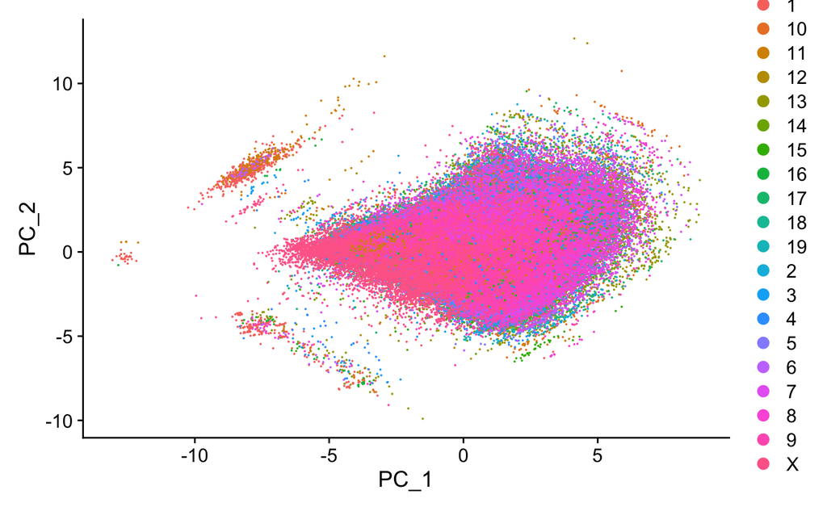

```r
DimPlot(marks_PCA, reduction = "pca", raster = FALSE)
```

```r
#DimHeatmap(marks_PCA, dims = 1:5, balanced = TRUE)
```

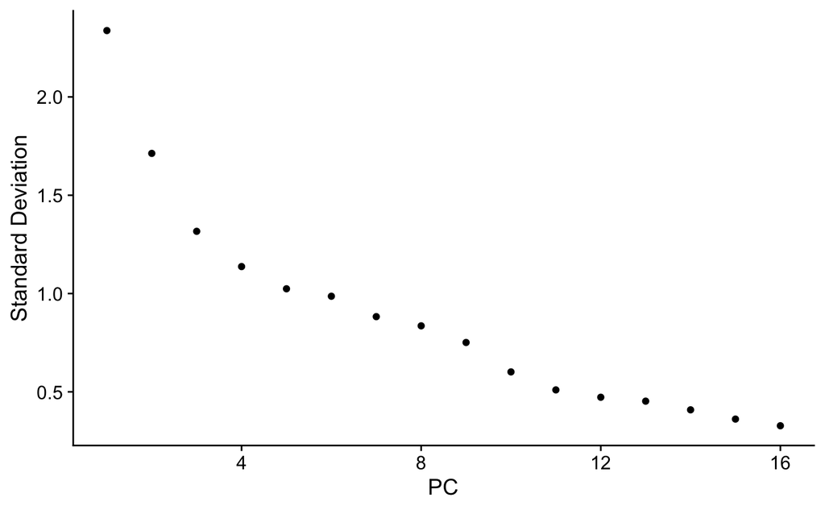

```r
ElbowPlot(marks_PCA)
```

Clustering

-> KNN graph based on euclidean distance in PCA space with edge weights between samples by Jaccard similarity (overlap in local neighbourhoods) -> Louvain clustering

```r
marks_KNN <- FindNeighbors(marks_PCA, dims = 1:12)
marks_Louvain <- FindClusters(marks_KNN, resolution = 1)
```

```
Modularity Optimizer version 1.3.0 by Ludo Waltman and Nees Jan van Eck

Number of nodes: 251254
Number of edges: 5958936

Running Louvain algorithm...
```

```
Maximum modularity in 10 random starts: 0.8286
Number of communities: 31
Elapsed time: 174 seconds
```

I ran several iterations with different parameters to check what made the most sense with the UMAP representation. dim 9, resolution 0.8 dim 9, resolution 1.2 dim 15, resolution 1 dim 12, resolution 1 (this is the one I settled on)

Look at cluster IDs

```r
Idents(marks_Louvain) %>%
  as.data.frame() %>%
  rownames_to_column(var = "interaction_ID") %>%
  rename(Louvain_cluster_ID = ".") -> Louvain_clusters
head(Louvain_clusters)
```

|  | interaction_ID | Louvain_cluster_ID |
| --- | --- | --- |
| 1 | 1_3100832_3102475...1_88213534_88213918 | 23 |
| 2 | 1_3100832_3102475...1_88219912_88220831 | 23 |
| 3 | 1_3100832_3102475...1_88220832_88222715 | 23 |
| 4 | 1_3100832_3102475...1_88239615_88243256 | 23 |
| 5 | 1_3100832_3102475...1_88248977_88249989 | 23 |
| 6 | 1_3100832_3102475...1_88249990_88253144 | 23 |

Now incorporating this info in the original table

```r
marks_import %>%
  left_join(Louvain_clusters) -> marks_2
head(marks_2)
```

| interaction_ID | UMAP1 | UMAP2 | P_ID | PIR_ID | P_gene | PIR_gene | CHiC_DNMT_KO_EpiLC_D2 | CHiC_DNMT_KO_ES_D0 | CHiC_DNMT_WT_EpiLC_D2 | CHiC_DNMT_WT_ES_D0 | CHiC_TET_KO_EpiLC_D2 | CHiC_TET_KO_ES_D0 | CHiC_TET_WT_EpiLC_D2 | CHiC_TET_WT_ES_D0 | P_mC_DNMT_WT_ES_D0 | P_mC_DNMT_WT_EpiLC_D2 | P_mC_TET_WT_ES_D0 | P_mC_TET_WT_EpiLC_D2 | P_mC_TET_KO_ES_D0 | P_mC_TET_KO_EpiLC_D2 | PIR_mC_DNMT_WT_ES_D0 | PIR_mC_DNMT_WT_EpiLC_D2 | PIR_mC_TET_WT_ES_D0 | PIR_mC_TET_WT_EpiLC_D2 | PIR_mC_TET_KO_ES_D0 | PIR_mC_TET_KO_EpiLC_D2 | P_hmC_TET_WT_ES_D0 | P_hmC_TET_WT_EpiLC_D2 | P_hmC_DNMT_WT_EpiLC_D2 | … |
| --- | --- | --- | --- | --- | --- | --- | --- | --- | --- | --- | --- | --- | --- | --- | --- | --- | --- | --- | --- | --- | --- | --- | --- | --- | --- | --- | --- | --- | --- | --- |
| 1_3100832_3102475...1_88213534_88213918 | -7.736398 | 2.661268 | 1_3100832_3102475 | 1_88213534_88213918 | NA | NA | 8.110911 | 21.034346 | 7.1204144 | 1.225626 | 0.000000 | 0.0000000 | 0.0000000 | 1.563273 | 1.158808 | 37.17698 | 18.98997 | 42.52453 | 49.0287 | 75.91344 | 2.302630 | 42.73777 | 24.25998 | 46.52147 | 42.17809 | 60.20813 | 0.05197199 | 0.008601253 | 0.01589082 | … |
| 1_3100832_3102475...1_88219912_88220831 | -7.640635 | 2.543528 | 1_3100832_3102475 | 1_88219912_88220831 | NA | NA | 1.343195 | 21.017586 | 0.9616277 | 7.499996 | 20.274226 | 19.7786822 | 13.6465230 | 20.009313 | 1.158808 | 37.17698 | 18.98997 | 42.52453 | 49.0287 | 75.91344 | 3.683014 | 39.84996 | 18.71493 | 39.16750 | 38.14064 | 53.40742 | 0.05197199 | 0.008601253 | 0.01589082 | … |
| 1_3100832_3102475...1_88220832_88222715 | -7.588283 | 2.662663 | 1_3100832_3102475 | 1_88220832_88222715 | NA | NA | 7.673024 | 14.235392 | 0.9616498 | 13.996533 | 13.610329 | 19.7796432 | 7.1979752 | 7.093898 | 1.158808 | 37.17698 | 18.98997 | 42.52453 | 49.0287 | 75.91344 | 3.683014 | 39.84996 | 18.71493 | 39.16750 | 38.14064 | 53.40742 | 0.05197199 | 0.008601253 | 0.01589082 | … |
| 1_3100832_3102475...1_88239615_88243256 | -7.587952 | 2.421477 | 1_3100832_3102475 | 1_88239615_88243256 | NA | NA | 1.343565 | 21.037692 | 13.5127725 | 13.997334 | 7.148573 | 6.9134002 | 13.6471740 | 7.094377 | 1.158808 | 37.17698 | 18.98997 | 42.52453 | 49.0287 | 75.91344 | 1.906809 | 54.41014 | 22.50960 | 49.08160 | 50.25687 | 69.41440 | 0.05197199 | 0.008601253 | 0.01589082 | … |
| 1_3100832_3102475...1_88248977_88249989 | -7.611894 | 2.500078 | 1_3100832_3102475 | 1_88248977_88249989 | NA | NA | 1.343706 | 0.000000 | 0.9620860 | 1.226275 | 7.148706 | 13.2586298 | 13.6474078 | 7.094573 | 1.158808 | 37.17698 | 18.98997 | 42.52453 | 49.0287 | 75.91344 | 1.221640 | 43.32586 | 19.20653 | 49.06848 | 43.35247 | 65.98791 | 0.05197199 | 0.008601253 | 0.01589082 | … |
| 1_3100832_3102475...1_88249990_88253144 | -7.732681 | 2.650164 | 1_3100832_3102475 | 1_88249990_88253144 | NA | NA | 1.343742 | 1.283993 | 7.1213814 | 1.226313 | 7.148740 | 0.8116416 | 0.9978581 | 20.009270 | 1.158808 | 37.17698 | 18.98997 | 42.52453 | 49.0287 | 75.91344 | 1.342959 | 47.28128 | 21.61995 | 50.53860 | 46.85413 | 68.49798 | 0.05197199 | 0.008601253 | 0.01589082 | … |

Plotting the original clusters

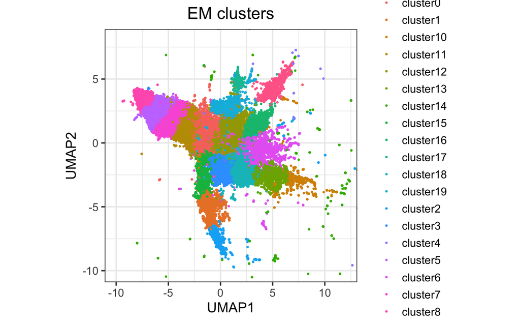

```r
marks_2 %>%
  slice_sample(prop = 0.1) %>%
  ggplot(aes(UMAP1, UMAP2, colour = cluster_ID)) +
  geom_point(size = 0.5) +
  theme_bw(base_size = 14) +
  ggtitle("EM clusters") +
  coord_cartesian(xlim = c(-10, 12), ylim = c(-10, 8)) +
  theme(aspect.ratio = 1, plot.title = element_text(hjust = 0.5))
```

Plotting the Louvain clusters

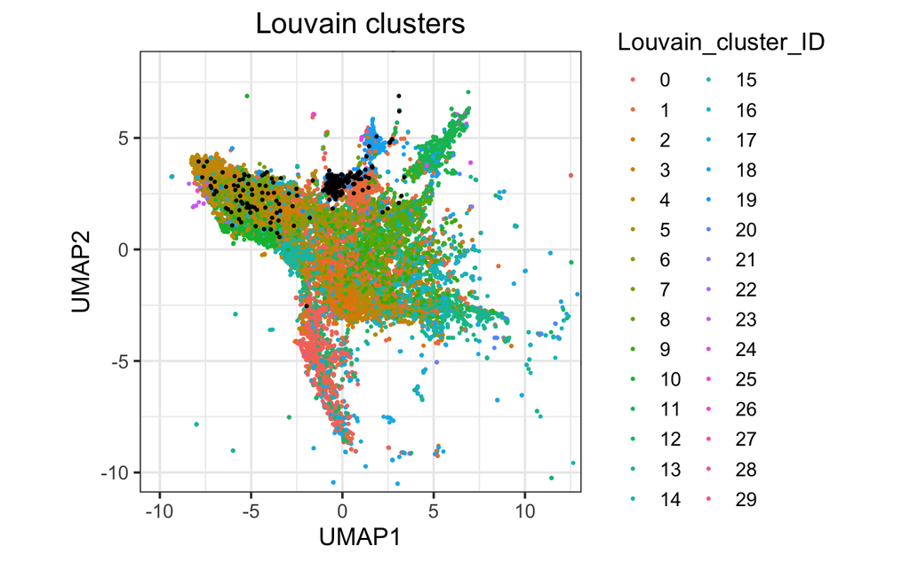

```r
marks_2 %>%
  slice_sample(prop = 0.05) %>%
  ggplot(aes(UMAP1, UMAP2, colour = Louvain_cluster_ID)) +
  geom_point(size = 0.5) +
  geom_point(data = marks_2 %>% slice_sample(prop = 0.05) %>% filter(Louvain_cluster_ID == 19), size = 0.5, colour = "black") +
  theme_bw(base_size = 14) +
  ggtitle("Louvain clusters") +
  coord_cartesian(xlim = c(-10, 12), ylim = c(-10, 8)) +
  theme(aspect.ratio = 1, plot.title = element_text(hjust = 0.5))
```

Okay, let’s explore these a bit more.

How many regions per cluster?

```r
marks_2 %>%
  group_by(Louvain_cluster_ID) %>%
  count()
```

| Louvain_cluster_ID | n |
| --- | --- |
| 0 | 21619 |
| 1 | 19734 |
| 2 | 17550 |
| 3 | 15888 |
| 4 | 14713 |
| 5 | 14600 |
| 6 | 14572 |
| 7 | 13899 |
| 8 | 13342 |
| 9 | 13183 |

[output cut: 21 more lines]

Looking at marks per cluster

```r
marks_2 %>%
  select(-UMAP1, -UMAP2, -P_ID, -PIR_ID, -P_gene, -PIR_gene, -contains("DNMT"), -contains("ES"), -contains("Input"), -contains("KO"), -contains("CHiC")) %>%
  select(interaction_ID, cluster_ID, cluster_group, Louvain_cluster_ID, everything()) %>%
  pivot_longer(5:last_col(), names_to = "condition", values_to = "values") %>%
  separate(condition, into = c("region", "mark")) -> marks_TET_Epi_long
```

```
Warning: Expected 2 pieces. Additional pieces discarded in 4020064 rows [1, 2, 3, 4, 5, 6, 7, 8, 9, 10, 11, 12, 13, 14, 15, 16, 17, 18, 19, 20, ...].
```

The warning here is fine, I deliberately discard the additional pieces.